# Data quality

What the GPS, physical capability and recovery files contain, how they join, and what the pipeline must handle

Author

Michael Davies

Published

20 October 2026

The Chelsea FC Performance Insights Vizathon 2025 dataset contains **simulated data for one player**. This report covers the three daily files: GPS, physical capability and recovery. It records what each file holds, checks it against the data guide and against itself, and sets out the cleaning rules the pipeline will follow. Every number below is calculated from the data when this report renders.

## Summary

The data is clean in the ways that matter most for joining: every file has exactly one row per date (and per test or metric), dates parse without error, and missing values are recorded consistently. One thing needs handling before analysis, and two more need care:

## All checks

[output not shown]

## The files

### GPS

862 rows, one per calendar day from 2 August 2022 to 11 April 2025, including 147 match days. Days without a session are stored as rows of zeros (141 days), so averages must exclude them. Match-day codes count up to 10 in both directions and stop there, so “10” means “10 or more”. Heart rate zones arrive as minutes and seconds; the reader converts them to minutes.

### Physical capability

12,400 rows: 20 combinations of movement (agility, jump, sprint, upper body), quality and expression (isometric or dynamic), every day from 2 July 2023 to 12 March 2025. The score is a benchmark percentage that can exceed 100% or fall below 0. Across all combinations there are 832 genuine results on 252 test days.

### Recovery status

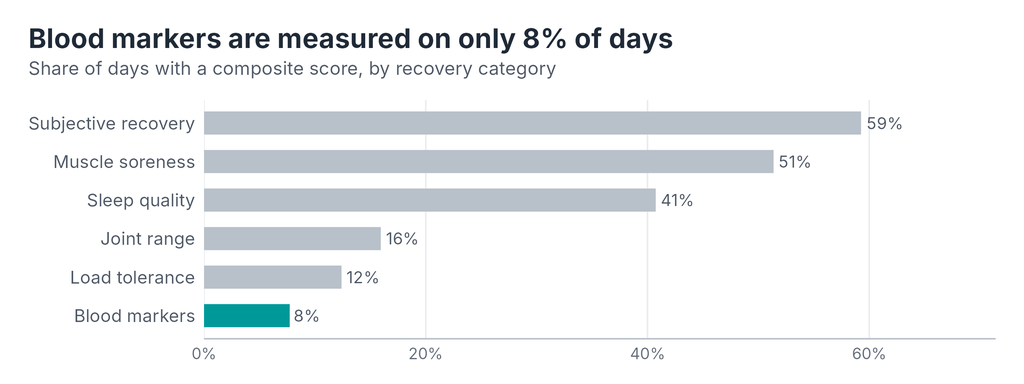

8,073 rows in long format: 13 metrics a day from 2 July 2023 to 13 March 2025. Each of six categories has a completeness score (0 to 1) and a composite score relative to the player’s norm, plus one overall score. Missing means not collected; zero is a real zero. Infrequent tests such as blood markers will need carrying forward, with their age shown, if they are to sit on a daily view.

**Pre-season recovery scores.** Recovery is also collected through pre-season, when there is no GPS data. 46 days (July 2023 and July 2024) have recovery scores but no GPS row, so they have no day of the match week; scores are collected six days a week then, with none on Sundays. The pipeline removes them, for two reasons:

- **No load context.** With no GPS before them, there is no record of the training a score is responding to, so it can’t be read against the load that came before it.
- **The benchmark is already given.** Each score is already relative to the player’s norm (0%), so these weeks are not needed to establish what normal looks like.

They are kept in the staging schema, as received, and dropped when the monitoring tables are built.

#### When each marker is collected

Recovery scores are not collected every day, and which days they fall on matters: a marker that is rarely taken the day after a match can’t show the response to that match. Each tab shows the share of days a score exists, by day of the match week.

**Overall recovery score**

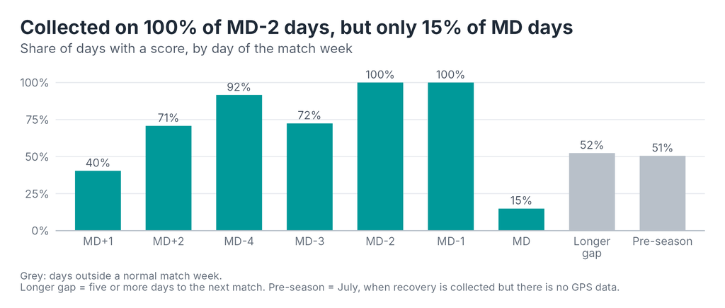

**Blood markers**

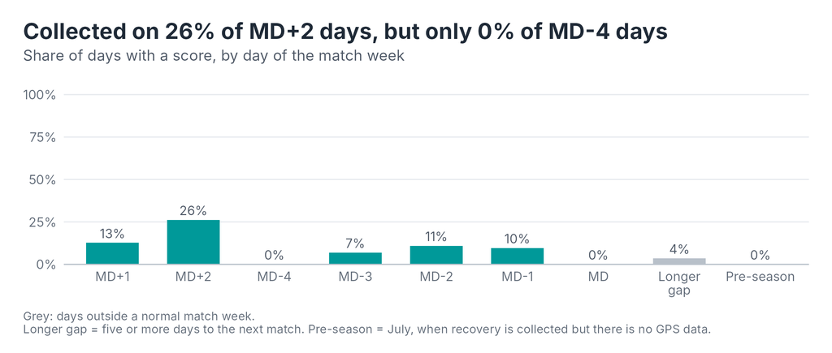

**Joint range**

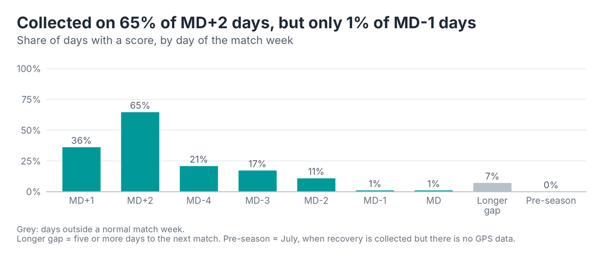

**Load tolerance**

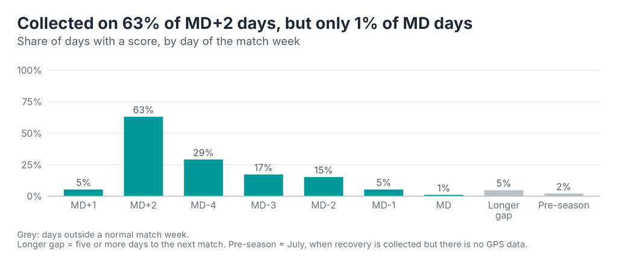

**Subjective recovery**

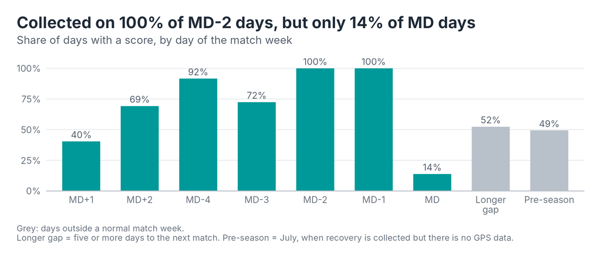

**Muscle soreness**

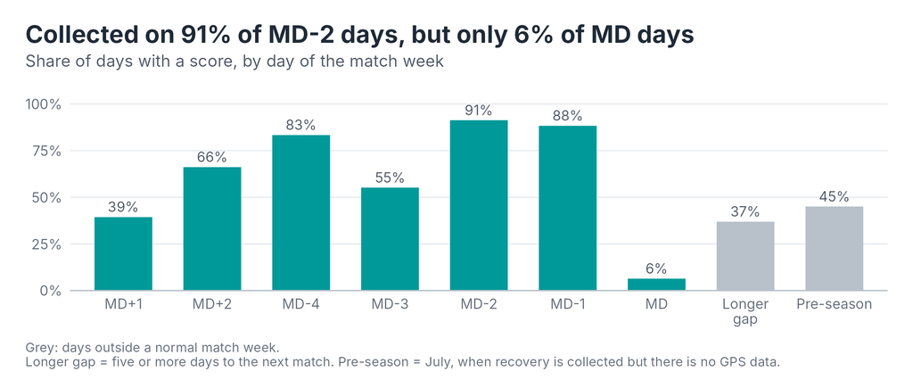

**Sleep quality**

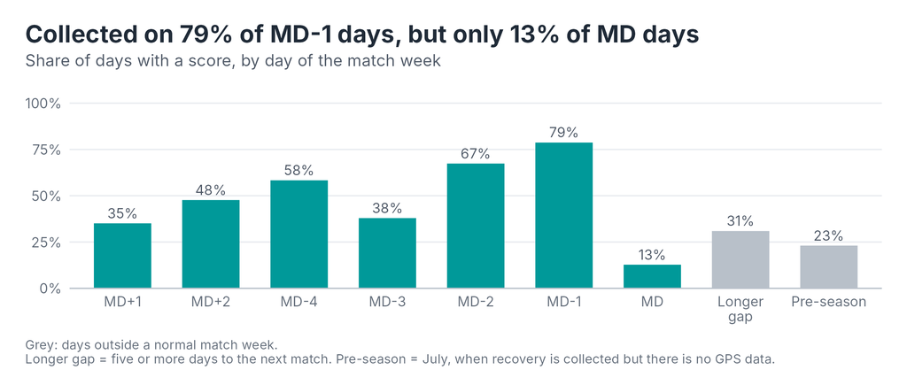

The overall score and subjective recovery are collected on nearly every MD-2 and MD-1, but on far fewer MD+1s and few match days. Joint range and load tolerance are concentrated on MD+2, and blood markers on MD+1 and MD+2. Any analysis of recovery after a match has to account for this: apart from match day itself, MD+1 is the day the overall score is most often missing.

## How the files join

All three files describe one player, so **date is the only join key**. The GPS and recovery files have one row per day and join directly; capability joins on date once reduced to new results.

| From | To | Key | Notes |
| --- | --- | --- | --- |
| GPS | Recovery | `date` | 529 GPS days in the overlap, all with a recovery row |
| GPS | Capability | `date` = `test_date` | Join to the most recent result on or before each date |

## Rules for the pipeline

1. Read the GPS file as Latin-1, and parse all dates as day/month/year.
2. Keep GPS rows of zeros as days without a session; exclude them from averages and load totals.
3. Treat match-day code 10 as “10 or more” and derive match context from `md_plus_code == 0`.
4. Reduce capability data to new results before calculating trends, test frequency or change.
5. Keep benchmark scores uncapped; they are relative scores, not percentiles.
6. Treat missing recovery values as not collected; keep zeros as measured values.
7. Use the overall recovery score as supplied rather than recomputing it.
8. Remove recovery scores from days with no GPS row (the July pre-season weeks).
9. Restrict combined analyses to the overlap window, 2 July 2023 to 12 March 2025.

Data: CFC Insights Vizathon 2025, Chelsea FC Performance Insights (simulated data for one player). Raw files are downloaded from the public competition repository, not stored here, and loaded into the staging schema of the project’s DuckDB database before this report runs.